**(13/06/2022)**

# Assignment 5

# Sanket M. Bairagi

**Roll No. - 33**  
**M.Sc. Data Science And Big Data Analytics.**  
**B.K.Birla College Kalyan.**

## Task - KMeans Clustering On Iris Dataset Using Petal Length And Petal Width.

```python
# importing required libraries.

import pandas as pd
import numpy as np
import matplotlib.pyplot as plt
import seaborn as sns
import warnings

warnings.filterwarnings("ignore")
```

```python
# load iris dataset from seaborn library.

iris = sns.load_dataset("iris")
```

```python
# top 5 rows of iris dataset.

iris.head()
```

|  | sepal_length | sepal_width | petal_length | petal_width | species |
| --- | --- | --- | --- | --- | --- |
| 0 | 5.1 | 3.5 | 1.4 | 0.2 | setosa |
| 1 | 4.9 | 3.0 | 1.4 | 0.2 | setosa |
| 2 | 4.7 | 3.2 | 1.3 | 0.2 | setosa |
| 3 | 4.6 | 3.1 | 1.5 | 0.2 | setosa |
| 4 | 5.0 | 3.6 | 1.4 | 0.2 | setosa |

```python
# shape of dataset.

iris.shape
```

```
(150, 5)
```

Iris dataset has 150 rows and 5 columns.

```python
# columns name in dataset.

iris.columns
```

```
Index(['sepal_length', 'sepal_width', 'petal_length', 'petal_width',
       'species'],
      dtype='object')
```

```python
iris.info()
```

```
<class 'pandas.core.frame.DataFrame'>
RangeIndex: 150 entries, 0 to 149
Data columns (total 5 columns):
 #   Column        Non-Null Count  Dtype
---  ------        --------------  -----
 0   sepal_length  150 non-null    float64
 1   sepal_width   150 non-null    float64
 2   petal_length  150 non-null    float64
 3   petal_width   150 non-null    float64
 4   species       150 non-null    object
dtypes: float64(4), object(1)
memory usage: 6.0+ KB
```

sepal_length,sepal_width,petal_length & petal_width are numerical columns. and species is categorical column.

```python
# check for null values

iris.isna().sum()
```

```
sepal_length    0
sepal_width     0
petal_length    0
petal_width     0
species         0
dtype: int64
```

there is no null values inside iris datset.

##### we will use K-mean alogorithm on patel_length and petal_width column of iris dataset for predict the clustor for 3 categoris , i.e either flower belongs to setosa,viriginica, or versicolor.

```python
iris.head()
```

|  | sepal_length | sepal_width | petal_length | petal_width | species |
| --- | --- | --- | --- | --- | --- |
| 0 | 5.1 | 3.5 | 1.4 | 0.2 | setosa |
| 1 | 4.9 | 3.0 | 1.4 | 0.2 | setosa |
| 2 | 4.7 | 3.2 | 1.3 | 0.2 | setosa |
| 3 | 4.6 | 3.1 | 1.5 | 0.2 | setosa |
| 4 | 5.0 | 3.6 | 1.4 | 0.2 | setosa |

```python
# tacking petal_length and Petal_width in X veriable.

X= iris.iloc[:,[2,3]].values
```

```python
X
```

```
array([[1.4, 0.2],
       [1.4, 0.2],
       [1.3, 0.2],
       [1.5, 0.2],
       [1.4, 0.2],
       [1.7, 0.4],
       [1.4, 0.3],
       [1.5, 0.2],
       [1.4, 0.2],
       [1.5, 0.1],
       [1.5, 0.2],
       [1.6, 0.2],
       [1.4, 0.1],
       [1.1, 0.1],
       [1.2, 0.2],
       [1.5, 0.4],
       [1.3, 0.4],
       [1.4, 0.3],
       [1.7, 0.3],
       [1.5, 0.3],
       [1.7, 0.2],
       [1.5, 0.4],
       [1. , 0.2],
       [1.7, 0.5],
       [1.9, 0.2],
       [1.6, 0.2],
       [1.6, 0.4],
       [1.5, 0.2],
       [1.4, 0.2],
       [1.6, 0.2],
       [1.6, 0.2],
       [1.5, 0.4],
       [1.5, 0.1],
       [1.4, 0.2],
       [1.5, 0.2],
       [1.2, 0.2],
       [1.3, 0.2],
       [1.4, 0.1],
       [1.3, 0.2],
       [1.5, 0.2],
```

[output cut: 95 more lines]

```
       [6.1, 2.3],
       [5.6, 2.4],
       [5.5, 1.8],
       [4.8, 1.8],
       [5.4, 2.1],
       [5.6, 2.4],
       [5.1, 2.3],
       [5.1, 1.9],
       [5.9, 2.3],
       [5.7, 2.5],
       [5.2, 2.3],
       [5. , 1.9],
       [5.2, 2. ],
       [5.4, 2.3],
       [5.1, 1.8]])
```

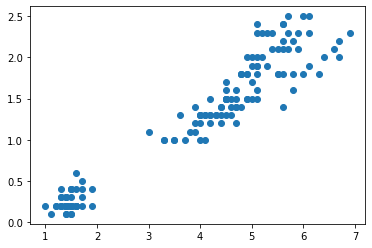

```python
# sccatter plot for the Petal_length vs. petal_width.

plt.scatter(X[:,0],X[:,1])
plt.show()
```

from above scatter plot we assume that there is 2 clustors.

```python
# Importing library.

from sklearn.cluster import KMeans
```

```python
#fitting the model.

kmean=KMeans(n_clusters=2)
kmean.fit(X)
```

```
KMeans(n_clusters=2)
```

```python
# centroiids of clustors.

kmean.cluster_centers_
```

```
array([[4.92525253, 1.68181818],
       [1.49215686, 0.2627451 ]])
```

```python
# lables of clustores.

kmean.labels_
```

```
array([1, 1, 1, 1, 1, 1, 1, 1, 1, 1, 1, 1, 1, 1, 1, 1, 1, 1, 1, 1, 1, 1,
       1, 1, 1, 1, 1, 1, 1, 1, 1, 1, 1, 1, 1, 1, 1, 1, 1, 1, 1, 1, 1, 1,
       1, 1, 1, 1, 1, 1, 0, 0, 0, 0, 0, 0, 0, 0, 0, 0, 0, 0, 0, 0, 0, 0,
       0, 0, 0, 0, 0, 0, 0, 0, 0, 0, 0, 0, 0, 0, 0, 0, 0, 0, 0, 0, 0, 0,
       0, 0, 0, 0, 0, 0, 0, 0, 0, 0, 1, 0, 0, 0, 0, 0, 0, 0, 0, 0, 0, 0,
       0, 0, 0, 0, 0, 0, 0, 0, 0, 0, 0, 0, 0, 0, 0, 0, 0, 0, 0, 0, 0, 0,
       0, 0, 0, 0, 0, 0, 0, 0, 0, 0, 0, 0, 0, 0, 0, 0, 0, 0])
```

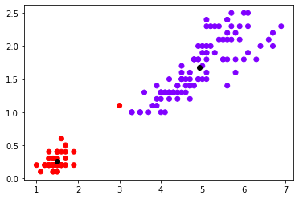

```python
# plotting scatterplot for the closters.

plt.scatter(X[:,0], X[:,1], c=kmean.labels_ , cmap="rainbow")
plt.scatter(kmean.cluster_centers_[:,0] , kmean.cluster_centers_[:,1],color="black")
plt.show()
```

from above scatter plot, we can see two clustors, out of two, one clustor has more points as well as its spread is high as compare to other one. it may possible that there is one more clustor is present. to get accurate no. of clustors we will perfom Elbow Method.

### Elbow Method.

```python
# we will perform this Elbow method for clustor 2 to clustor 5.


from sklearn.cluster import KMeans
wcss = []

for i in range(2,5):
    kmeans = KMeans(n_clusters=i)
    kmeans.fit(X)
    wcss.append(kmeans.inertia_)
print(wcss)
```

```
[86.39021984551395, 31.371358974358976, 19.483000899685113]
```

```python
len(wcss)
```

```
3
```

```python
avg=sum(wcss)/len(wcss)
avg
```

```
45.74819323985269
```

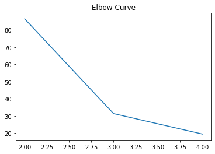

```python
plt.plot(range(2,5),wcss)
plt.title("Elbow Curve")
plt.show()
```

form above graph we will take clustor no. is 3.

```python
#fitting the model.

kmean2=KMeans(n_clusters=3)
kmean2.fit(X)
```

```
KMeans(n_clusters=3)
```

```python
# centroiids of clustors.

kmean2.cluster_centers_
```

```
array([[1.462     , 0.246     ],
       [5.59583333, 2.0375    ],
       [4.26923077, 1.34230769]])
```

```python
# lables of clustores.

kmean2.labels_
```

```
array([0, 0, 0, 0, 0, 0, 0, 0, 0, 0, 0, 0, 0, 0, 0, 0, 0, 0, 0, 0, 0, 0,
       0, 0, 0, 0, 0, 0, 0, 0, 0, 0, 0, 0, 0, 0, 0, 0, 0, 0, 0, 0, 0, 0,
       0, 0, 0, 0, 0, 0, 2, 2, 2, 2, 2, 2, 2, 2, 2, 2, 2, 2, 2, 2, 2, 2,
       2, 2, 2, 2, 2, 2, 2, 2, 2, 2, 2, 1, 2, 2, 2, 2, 2, 1, 2, 2, 2, 2,
       2, 2, 2, 2, 2, 2, 2, 2, 2, 2, 2, 2, 1, 1, 1, 1, 1, 1, 2, 1, 1, 1,
       1, 1, 1, 1, 1, 1, 1, 1, 1, 2, 1, 1, 1, 1, 1, 1, 2, 1, 1, 1, 1, 1,
       1, 1, 1, 1, 1, 1, 2, 1, 1, 1, 1, 1, 1, 1, 1, 1, 1, 1])
```

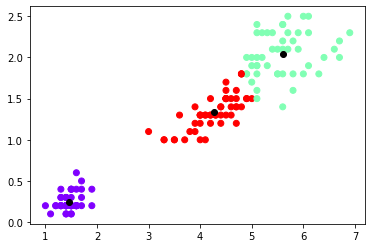

```python
# plotting scatterplot for the closters.

plt.scatter(X[:,0], X[:,1], c=kmean2.labels_ , cmap="rainbow")
plt.scatter(kmean2.cluster_centers_[:,0] , kmean2.cluster_centers_[:,1],color="black")
plt.show()
```

here we get 3 clustors.

```python
# making datframe  to check predicted clustor with actual data.
data2= pd.DataFrame({"petal_legth":iris.petal_length,"petal_width":iris.petal_width,"Actual Species":iris.species,"Predicted Clustor":kmean2.labels_ , })
```

```python
data2.head()
```

|  | petal_legth | petal_width | Actual Species | Predicted Clustor |
| --- | --- | --- | --- | --- |
| 0 | 1.4 | 0.2 | setosa | 0 |
| 1 | 1.4 | 0.2 | setosa | 0 |
| 2 | 1.3 | 0.2 | setosa | 0 |
| 3 | 1.5 | 0.2 | setosa | 0 |
| 4 | 1.4 | 0.2 | setosa | 0 |

```python
# applying lambda function on Species column
data2["Predicted species"]= data2.apply(lambda y : "setosa" if y["Predicted Clustor"]==0  else ("virginica" if y["Predicted Clustor"]==1 else "versicolor"),axis=1)
```

```python
data2
```

|  | petal_legth | petal_width | Actual Species | Predicted Clustor | Predicted species |
| --- | --- | --- | --- | --- | --- |
| 0 | 1.4 | 0.2 | setosa | 0 | setosa |
| 1 | 1.4 | 0.2 | setosa | 0 | setosa |
| 2 | 1.3 | 0.2 | setosa | 0 | setosa |
| 3 | 1.5 | 0.2 | setosa | 0 | setosa |
| 4 | 1.4 | 0.2 | setosa | 0 | setosa |
| ... | ... | ... | ... | ... | ... |
| 145 | 5.2 | 2.3 | virginica | 1 | virginica |
| 146 | 5.0 | 1.9 | virginica | 1 | virginica |
| 147 | 5.2 | 2.0 | virginica | 1 | virginica |
| 148 | 5.4 | 2.3 | virginica | 1 | virginica |
| 149 | 5.1 | 1.8 | virginica | 1 | virginica |

150 rows × 5 columns

```python
# use where fuction to get the location where prediction is wronge.

np.where(data2["Actual Species"]!=data2["Predicted species"])
```

```
(array([ 77,  83, 106, 119, 126, 138], dtype=int64),)
```

we get 6 location where our prediction goes wronge.

```python
pd.DataFrame(data2.iloc[77])
```

|  | 77 |
| --- | --- |
| petal_legth | 5.0 |
| petal_width | 1.7 |
| Actual Species | versicolor |
| Predicted Clustor | 1 |
| Predicted species | virginica |

```python
pd.DataFrame(data2.iloc[83])
```

|  | 83 |
| --- | --- |
| petal_legth | 5.1 |
| petal_width | 1.6 |
| Actual Species | versicolor |
| Predicted Clustor | 1 |
| Predicted species | virginica |

```python
pd.DataFrame(data2.iloc[106])
```

|  | 106 |
| --- | --- |
| petal_legth | 4.5 |
| petal_width | 1.7 |
| Actual Species | virginica |
| Predicted Clustor | 2 |
| Predicted species | versicolor |

```python
pd.DataFrame(data2.iloc[119])
```

|  | 119 |
| --- | --- |
| petal_legth | 5.0 |
| petal_width | 1.5 |
| Actual Species | virginica |
| Predicted Clustor | 2 |
| Predicted species | versicolor |

```python
pd.DataFrame(data2.iloc[126])
```

|  | 126 |
| --- | --- |
| petal_legth | 4.8 |
| petal_width | 1.8 |
| Actual Species | virginica |
| Predicted Clustor | 2 |
| Predicted species | versicolor |

```python
pd.DataFrame(data2.iloc[138])
```

|  | 138 |
| --- | --- |
| petal_legth | 4.8 |
| petal_width | 1.8 |
| Actual Species | virginica |
| Predicted Clustor | 2 |
| Predicted species | versicolor |